# Review Guide for Midterm 1 Exam

STAT 218: Applied Statistics for Life Science

# What to Expect

- You may bring an $8 \frac{1}{2} \times 11$ standard sheet of notes (both sides). I will not provide you with formulas, so put what you think you need on here.
- You will turn this in with your exam so make sure you put your name on it.
- You may bring any calculator to use. I will have a handful of simple calculators. You may **not** use your phone as a calculator.
- The exam is mostly multiple choice, but will have a handful of short answer questions mixed in.
- You will have 50 minutes to complete the exam. It took me approximately 15 minutes to complete.

**Canvas Discussion Board**

Post any logistic or studying questions on the Canvas discussion board. Please respond to each other!

Solutions to the review will *not* be posted.

# Key Concepts to Review

# Practice Problems

1. Suppose a governor is concerned about their “negatives” (i.e., the percentage of state residents who express disapproval with their job performance). Their campaign pays for a series of television ads, hoping that they can keep the negatives below 30%. They use follow-up polling to assess the ads’ effectiveness. Their hypotheses are as follows:

$H_0:$ The ads are not effective

$H_A:$ The ads are effective (i.e., the negatives are below 30%)

The negatives come in at 22%, and the p-value obtained is 0.08.

1. Which of the following is the most correctly written conclusion given a significance level of 0.05?
> 1. We have evidence that the ads are effective.
> 2. We have evidence that the ads are not effective.
> 3. There is not enough evidence to conclude that the ads are effective.
> 4. We have evidence that 8% of the state residents disapprove of the governor.
2. Which of the following is the most correctly written conclusion given a significance level of 0.10?
> 1. We have evidence that the ads are effective.
> 2. We have evidence that the ads are not effective.
> 3. There is not enough evidence to conclude that the ads are effective.
> 4. We have evidence that 8% of the state residents disapprove of the governor.
3. Recall that the p-value was 0.08. Which of the following is the most correct interpretation of this p-value?
> 1. There is an 8% chance that the ads were effective.
> 2. There is an 8% chance that the ads were not effective.
> 3. There is an 8% chance that a state resident disapproves of the governor.
> 4. There is an 8% chance that the poll could have resulted in 22% or fewer negatives even if the ads were not effective.
4. Suppose instead, our alternative is to test whether the negatives are different from 30%. What would you expect your p-value to be?
> 1. 0.08
> 2. 0.16
> 3. 0.04
> 4. 0.22
2. A large university is curious if they should build another cafeteria. They plan to survey their students to see if there is strong evidence that the proportion interested in a meal plan is higher than 40%, in which case they will consider building a new cafeteria.

> In a random sample of 200 students, 95 expressed interest in a meal plan.
1. State the parameter of interest.
2. State the Null and Alternative Hypotheses in symbols.
3. Carry out a simulation study to test the hypotheses. What are the inputs for the single proportion applet?
4. *Interpret* the p-value. Note this is not the conclusion or asking you to make a decision, but to interpret.
22. State a conclusion in context of the research question.
3. A random sample of 200 students is surveyed on a university campus. They are asked if they use a laptop in class to take notes. Suppose that based on the survey, 70 of the 200 students responded “yes.” Your goal is to estimate the true proportion of all students on this campus who use a laptop to take notes.
1. Find the observed statistic (also called the point estimate).
2. Find the margin of error associated with the 95% confidence interval.
3. Construct a 95% confidence interval for the true proportion of all students on this campus who use a laptop to take notes.
4. Suppose, instead, the survey results found that 175 out of 500 students responded “yes.” How will your confidence interval change?
> 1. The center of the confidence interval will increase.
> 2. The center of the confidence interval will decrease.
> 3. The confidence interval will be wider.
> 4. The confidence interval will be narrower.
4. Suppose that 500 Cal Poly students were surveyed to find a 95% confidence interval for the proportion of all Cal Poly students who have cheated on a test. Answer the following questions by circling your response.
1. TRUE / FALSE: The population proportion (i.e., the proportion of all Cal Poly students who have cheated on a test) will definitely be contained in the confidence interval.
2. TRUE / FALSE: The sample proportion (i.e., the sample statistic) will definitely be contained in this confidence interval.
3. TRUE / FALSE: This confidence interval can be used only to describe the 500 students who were surveyed; it cannot be used to make a statement about all Cal Poly students.
4. TRUE / FALSE: If a 90% confidence interval were constructed instead of a 95% confidence interval, would you expect the width of the confidence interval to increase or decrease?
5. Suppose a 95% confidence interval constructed from a sample mean is (5.5, 10.5). Circle ALL true statement(s).
> 1. A 99% confidence interval constructed from the same sample mean will contain 8.
> 2. A 99% confidence interval constructed from the same sample mean will NOT contain 8.
> 3. A 90% confidence interval constructed from the same sample mean will NOT contain 8.
> 4. A 90% confidence interval constructed from the same sample mean will contain 8.
6. Suppose that two different surveys were conducted to investigate whether the majority of Minnesotans feel there is a shortage of affordable home options. In Survey A, 344 of 625 (55%) felt there was a shortage of affordable home options. In Survey B, 331 of 625 (53%) said they felt this way. Which survey (A or B) would result in a smaller p-value when testing whether the majority of Minnesotans feel there is a shortage of affordable home options? (3 pts)
> 1. The p-values would be the same since both surveys sampled the same number of subjects.
> 2. There is not enough information given to determine anything about the p-values.
> 3. Survey A
> 4. Survey B
7. Suppose you want to investigate the question, *“What proportion of Americans support stronger gun laws?”* Identify the observational unit and variable of interest. (2 pts)
   1. Observational unit = opinion on gun laws, variable = number of people who support stronger gun laws
   2. Observational unit = opinion on gun laws, variable = political affiliation
   3. Observational unit = an American, variable = opinion on gun laws
   4. Observational unit = an American, variable = number of people who support stronger gun laws
8. A student participates in a Coke versus Pepsi taste test. She correctly identifies which soda is which five times out of six tries. She claims that this proves that she can reliably tell the difference between the two soft drinks. You have studied statistics and you want to determine the probability of anyone getting at least five right out of six tries just by chance alone. Which of the following would provide an accurate estimate of that probability? (2 pts)
   1. Have the student repeat this experiment many times and calculate the percentage of times she correctly distinguishes between the brands.
   2. Simulate this on the computer with a 50% chance of guessing the correct soft drink on each try, and calculate the percent of times there are five or more correct guesses out of six trials.
   3. Repeat this experiment with a very large sample of people and calculate the percentage of people who make five correct guesses out of six tries.
   4. All of the methods listed above would provide an accurate estimate of the probability.
9. Researchers carried out a study to investigate whether two-year-old children learn words through overhearing the conversations of others. In this study, the child sat and watched while the experimenter introduced four new objects to another adult. All four objects were originally placed in a bucket so that they were hidden from sight. One of the four objects was considered the “target” object, and the other three were considered “neutral” objects. For each of the three neutral objects, the researcher would say, “I’ll show you this one” and then pull it out the bucket. However, before introducing the target object to the other adult, the researcher would say, “I’ll show you the toma.” After the child had overheard this conversation between the researcher and the other adult, the researcher presented all four objects to the child and asked him or her to find the “toma.” This was repeated for each of 12 two-year-old subjects, and the researchers kept track of how many could correctly identify the target object.

**Research Question:** Is there evidence that children learn new words through overhearing? In other words, is there evidence that more two-year-olds are correctly identifying the target object than we would expect by chance?

1. Which of the following gives the best description of the population of interest? (3 pts)
   1. The 12 two-year-olds observed in this study
   2. The 10 two-year-olds that correctly identified the target object
   3. The population proportion of all two-year-olds that would correctly identify the target object
   4. All two-year-olds
2. Suppose the researchers will conduct a simulation study to get an idea of what outcomes to anticipate if the two-year old toddlers are really not able to learn new words through overhearing and are simply guessing when asked to find the target object. Complete the following simulation setup, conducting 100 simulated runs, for the researchers to use (3 pts)

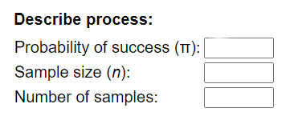

Suppose the researchers carried out 100 simulated runs of the experiment, and the number of two-year old toddlers that correctly identified the target object when guessing was recorded for each simulated run. The results are summarized below.

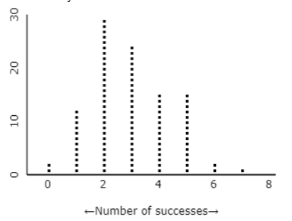

3. Evaluate the following statements based on the simulation results above. Circle the response that best reflects your conclusion. (2 pts each)
- If 3 two-year old toddlers correctly identified the target object, does this provide convincing evidence that children are learning new words from overhearing?

  Convinced Somewhat convinced Not convinced
- If 7 two-year old toddlers correctly identified the target object, does this provide convincing evidence that children are learning new words from overhearing?

  Convinced Somewhat convinced Not convinced
4. Why would it be important for the researchers to balance out the order in which the objects were presented to the two-year old toddlers across the study? For example, how would the study results have been affected if the researchers always presented the target object last? (3 pts)
10. A new delivery robot has been introduced on campus, offering an alternative to Grubhub for order-ahead pick-ups at the campus Panda Express. The university dining team wants to investigate whether the delivery robot is more accurate in fulfilling orders compared to Grubhub. An order is considered accurate if all items are correct and no items are missing. Previously, Grubhub had an accuracy rate of 80% for orders. To test the robot’s performance, the team randomly selects 120 orders fulfilled by the robot over a month and finds that 102 of them are accurate.

**Research Question** Is there evidence to suggest that the campus delivery robot improved the accuracy of orders at Panda Express?

1. Which of the following best describes the parameter of interest? (2 pts)
   1. The proportion of all orders that are accurate at Panda Express.
   2. The proportion of all orders accurately fulfilled by Grubhub.
   3. The proportion of all orders accurately fulfilled by the campus delivery robot.
   4. The proportion of all orders fulfilled by either the robot or Grubhub.
2. Calculate the sample statistic (assign a symbol and show how you obtained this value). (2 pts)
3. Write the null and alternative hypotheses for this study using *symbols*. (4 pts)

The following graph shows the simulated null sampling distribution for 100 simulations.

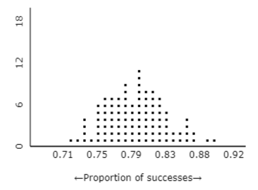

4. Where is the center of the sampling distribution? Explain why this center makes sense in the context of the study. (2 pts)
5. Use the simulated distribution to estimate the p-value for the observed proportion. Show your work directly on the graph. (3 pts)

   p-value = ________
6. Based on the p-value and an $\alpha = 0.05$, we would _____ the null hypothesis. (1 pt)
   1. Reject
   2. Fail to Reject
   3. Accept
7. Which of the following best describes the conclusion? (2 pts)
   1. At an $\alpha = 0.05,$ we have evidence to conclude that the campus delivery robot improved the accuracy of orders at Panda Express (p = xx).
   2. At an $\alpha = 0.05,$ we do not have enough evidence to conclude that the campus delivery robot improved the accuracy of orders at Panda Express (p = xx).
   3. At an $\alpha = 0.05,$ we have evidence to conclude that the campus delivery robot and Grubhub have the same accuracy of orders at Panda Express (p = xx).
   4. At an $\alpha = 0.05,$ we do not have enough evidence to conclude that the campus delivery robot and Grubhub have the same accuracy of orders at Panda Express (p = xx).
8. Suppose instead, the university dining team wanted to determine if there is evidence to suggest that the campus delivery robot changed the accuracy of orders at Panda Express. Which one of the following would change from the hypotheses in Question 3? (1 pt)
   1. Observed Sample Statistic
   2. Null hypothesis
   3. Alternative hypothesis
   4. Sample Size